# Exam

INTRODUCTION TO R

Mykola Chuprynskyy

2024

# 1 Guidelines (5 points)

Reproduce this HTML (including the guidelines), make the exercises and submit the **Rmd** file to Blackboard.

By following the guidelines below you can score 5 points:

- write your R code according to the style guides (1)
- resize plots if they are not approximately square (1)
- use the pipe operator to avoid making unnecessary objects (1)
- insert the image as in the original (1/2)
- suppress all R messages/warnings from being printed in the HTML (1/2)
- format the text as in the original (1/2)
- define the correct theme, the TOC and the section numbers in the YAML (1/2)

Success!!!

# 2 Data types (3 points)

1. Display the matrix shown below. To randomly generate the same logical values set the seed to 1. (1 point)

```
     X1    X2    X3    X4    X5   X6    X7    X8    X9   X10
a  TRUE FALSE FALSE  TRUE FALSE TRUE  TRUE  TRUE  TRUE FALSE
b FALSE  TRUE FALSE  TRUE FALSE TRUE  TRUE FALSE FALSE  TRUE
c  TRUE  TRUE  TRUE  TRUE FALSE TRUE FALSE FALSE  TRUE FALSE
d  TRUE  TRUE  TRUE FALSE  TRUE TRUE  TRUE FALSE  TRUE FALSE
```

2. Display the data object shown below. (1 point)

```
  X B
a 1 a
b 2 b
```

3. Display the data object shown below. (1 point)

```
$x
 [1] -10  -8  -6  -4  -2   0   2   4   6   8  10

$`length(x)`
[1] 11
```

The remaining exercises use the `starwars` data from the `dplyr` package. So …

[figure not shown]

# 3 Data exploration/manipulation (5 points)

1. Deselect the variables in `starwars` that are of class `list`. Overwrite the data and do not display the result. (1 point)
2. Display the frequencies of the hair colors of the human species. (1 point)

```
# A tibble: 10 × 2
   hair_color        n
   <chr>         <int>
 1 brown            14
 2 black             8
 3 blond             3
 4 none              3
 5 white             2
 6 auburn            1
 7 auburn, grey      1
 8 auburn, white     1
 9 brown, grey       1
10 grey              1
```

```
# A tibble: 2 × 3
  species mean_height frequency
  <chr>         <dbl>     <int>
1 Gungan         209.         3
2 Human          177.        31
```

# 4 Data visualization (5 points)

1. Display a histogram of `mass` with 20 bins and the x-axis converted to a logarithmic scale. Remove the cases with missing values from the plot. (1 point)

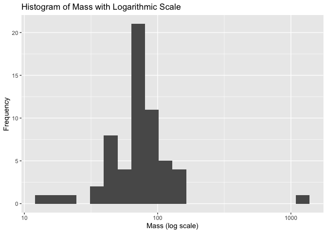

2. In a 1 x 2 plot array display two plots, one that shows the distribution of `sex` within categories of `hair_color` and one that shows the distribution of `height` within the categories of `eye_color`. Use an appropriate geom, and make sure that the axes labels are readable. (2 point)

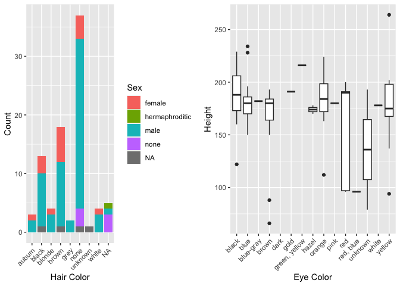

3. Remove cases with a `mass` larger than 1000 from the data, and display a scatter plot that shows the relationship between `height`, `mass` and `gender`. Use the theme `light`. (2 points)

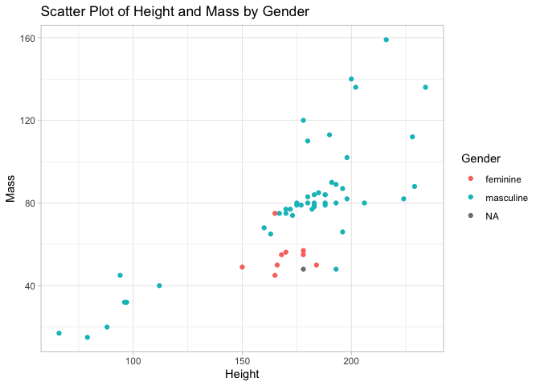

# 5 Linear Model (3 points)

Display the coefficients of the linear model predicting `mass` from `height` and `sex`. Which category of `sex` has the lowest predicted mass? (1 point)

```
                      Estimate  Std. Error   t value     Pr(>|t|)
(Intercept)        -52.8510871 12.44706631 -4.246068 8.809369e-05
height               0.6350786  0.06542516  9.706948 2.355785e-13
sexhermaphroditic 1299.7123324 17.94616933 72.422828 1.106770e-54
sexmale             20.8405093  6.25266197  3.333062 1.571721e-03
sexnone             33.6900833 10.40718704  3.237194 2.083998e-03
```

2. In a 2 x 2 plot array, display the residual plots of this model. (1 point)

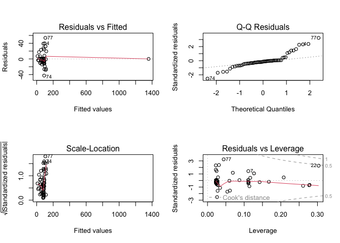

3. Answer the questions below about the assumptions of the model. (1 point)
   - The Normal Q-Q plot shows that the assumption of normality is satisfied/violated, because if the residuals are normally distributed, the points will lie approximately along a straight line.
   - The Residuals vs Fitted plot shows that the assumption of homoscdasticity is satisfied/violated, because if the residuals have constant variance (homoscedasticity), the points will be randomly dispersed around a horizontal line without a distinct pattern.
   - The Residuals vs Fitted plot shows that the assumption of linearity is satisfied/violated, because if the relationship is linear, the points will be randomly dispersed around a horizontal line without showing any systematic structure.

END OF EXAM

Submit your Rmd file to Blackboard.